# The logic of ggplot2

A Grammar of Graphics

Christophe Bontemps (SIAP)

[figure not shown]

## The 7 Components of a ggplot2 Chart

A *`ggplot2`* graphic is assembled from up to 7 parts (often less):

1. **Data** — the foundation
2. **Mapping** — translate data to aesthetics
3. **Layers** — geometric representations
4. *Scales* — control axes and legends*
5. *Facets* — small multiples*
6. *Coordinates* — spatial interpretation*
7. *Theme* — visual look & feel*

At minimum: **data**, a **mapping**, and one **layer**. Other layers (marked *) are optional.

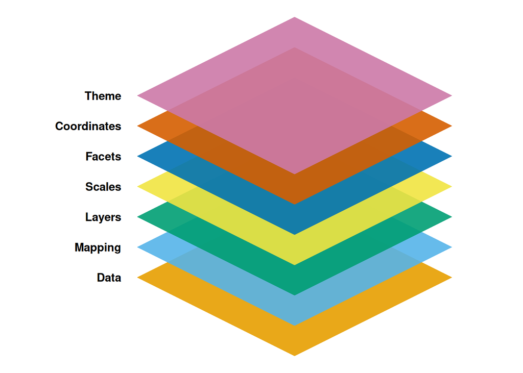

This presentation was directly inspired by the excellent - [Introduction to ggplot2](https://ggplot2.tidyverse.org) by Hadley Whickham et al.

## 1. Data and `ggplot()`

ggplot2 works best with **tidy data** (Rows = observations; Columns = variables)

The first step is to pass the data to `ggplot()`

```r
ggplot(data = mpg)
```

or

```r
mpg %>%
  ggplot()
```

This creates an empty canvas — no visual output yet, but the data is ready.

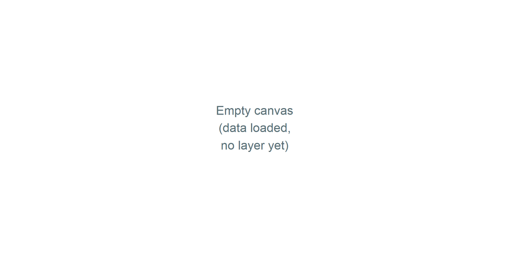

**The `mpg` dataset** used in all examples:

| Variable | Description |
| --- | --- |
| `cty`, `hwy` | City / highway mpg |
| `class` | Type of car |
| `drv` | Drive train |
| `displ` | Engine displacement |

## 2. Mapping: The link between variables and graphic attributes

A mapping links **variables** into **graphics attributes** (or aesthetic), acting as a dictionary between data and graphics.

```r
mpg %>%
  ggplot() +
  aes(x = cty, y = hwy)
```

The `aes()` function pairs:

- **Aesthetic**: `x`, `y`, `colour`, `fill`, with
- **Variables**: `cty`, `hwy`, `class` in `mpg` data set

This creates a frame with axis, scales and labels. No data yet.

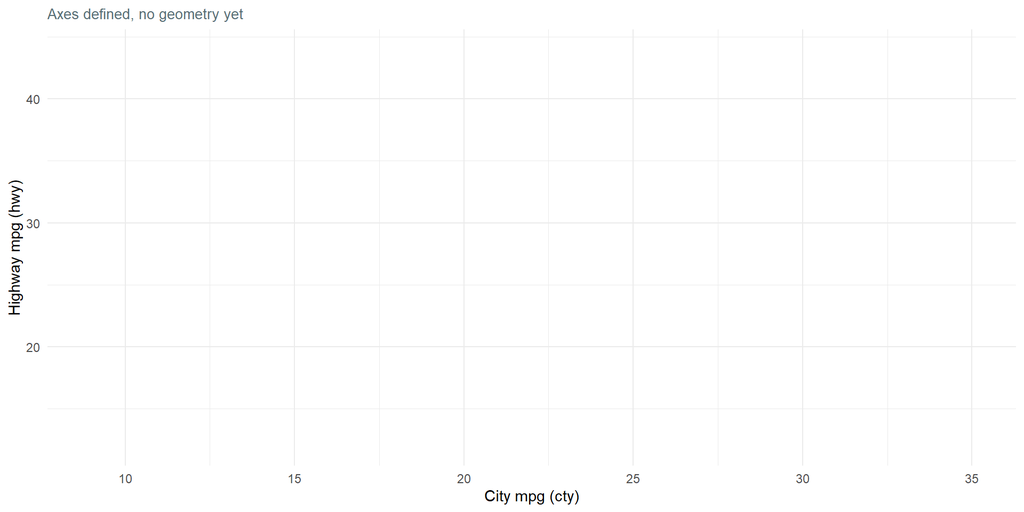

Key aesthetic attributes:

| Aesthetic | Controls |
| --- | --- |
| `x`, `y` | Position |
| `colour`, `fill` | Colour |
| `size`, `shape` | Point style |
| `alpha` | Transparency |

## 3. Layers: The heart of a ggplot2 chart

The most common layer is the **Geometry** defining *how* data is displayed

```r
mpg %>%
  ggplot() +
  aes(x = cty, y = hwy) +
  geom_point()              # scatterplot
```

One can add layers:

```r
mpg %>%
  ggplot() +
  aes(x = cty, y = hwy) +
  geom_point() +              # scatterplot
  geom_smooth(formula = y ~ x,
              method = "lm")  # linear trend
```

Two layers stacked with `+`:  
`geom_point()` + `geom_smooth()`

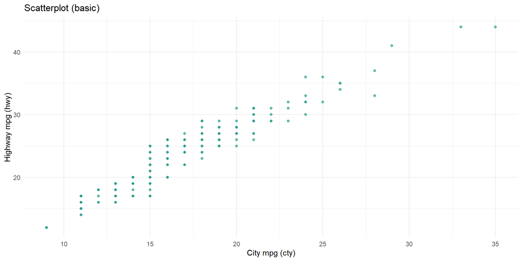

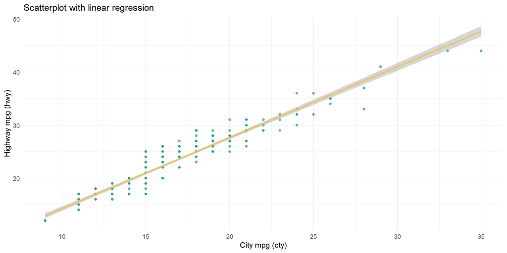

## 4. Scales

Scales **translate** what is shown on the graph back to an understanding of the data — axes, legends, colour, bars.

```r
mpg %>%
  ggplot() +
  aes(x = cty, y = hwy) +
  geom_point() +
  scale_colour_viridis_d()
```

Formally, `scale` is a function from a region in the data space (the domain of the scale) to a region in aesthetic space (the range of the scale).

[figure not shown]

**Scales controls**:

- Axis limits and breaks
- Label formatting
- Colour palettes
- Data transformations (`log`, `sqrt`…)

## 5. Facets: Graphics by groups

Facets split the data into **small multiples** and separate panels for subsets of the data according to a factor variable.

```r
mpg %>%
  ggplot() +
  aes(x = cty, y = hwy) +
  geom_point() +
  facet_grid(~year)
```

Two facet functions:

- `facet_grid(row ~ col)` — strict grid
- `facet_wrap(~ var)` — wraps into space

Here: 2 years = 2 panels or 2 years x 3 drives = 6 panels

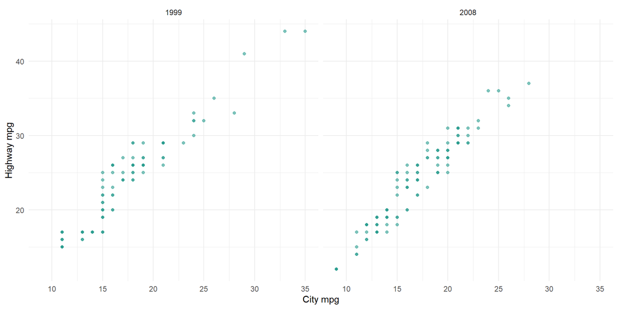

or with `facet_grid(year~drv)`

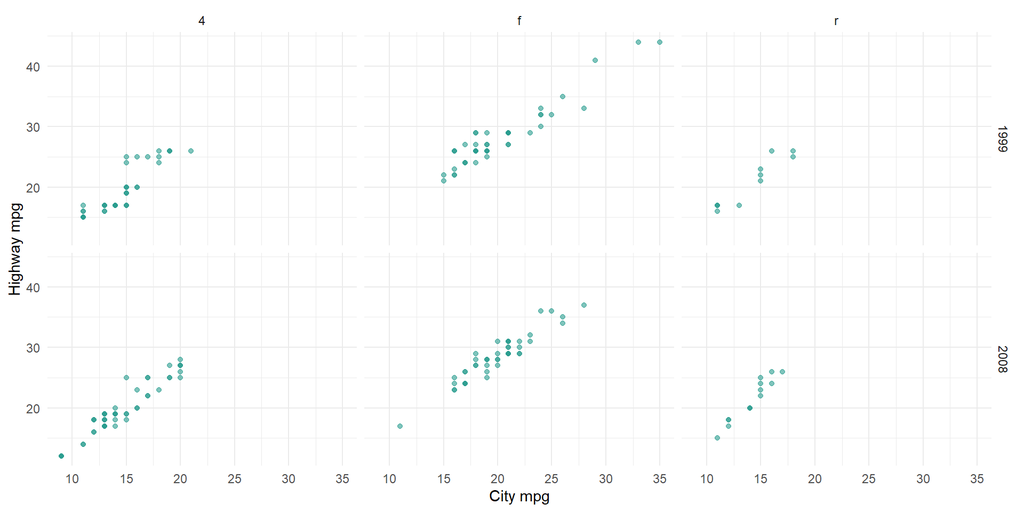

## 6. Coordinates: Fix positions

Coordinates interpret **position aesthetics**. The default is Cartesian, but alternatives exist:

```r
mpg %>%
  ggplot() +
  aes(x = cty, y = hwy) +
  geom_point() +
  coord_fixed()
```

Here: 1 unit on x = 1 unit on y, making slope visually meaningful.

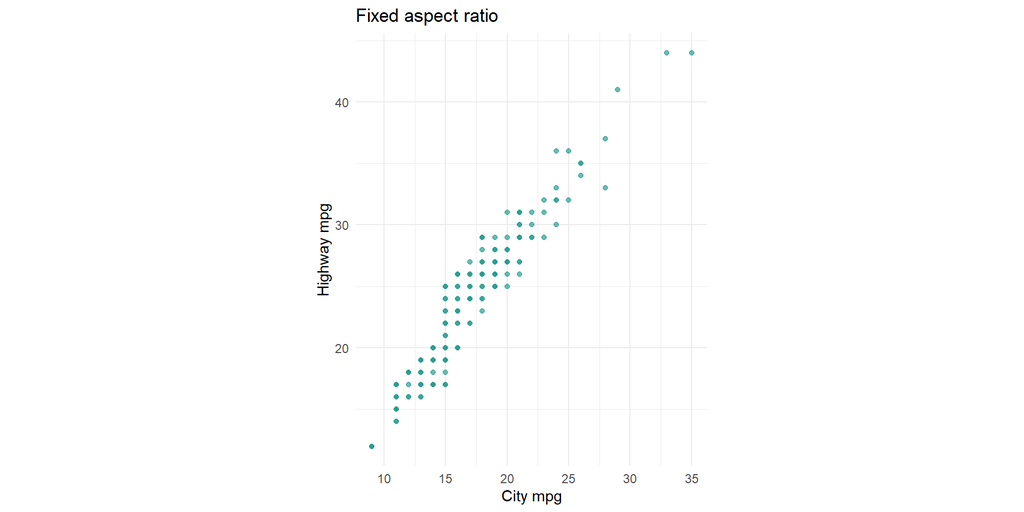

| Function | Use |
| --- | --- |
| `coord_fixed()` | Equal x/y units |
| `coord_flip()` | Swap x and y |
| `coord_polar()` | Polar / pie charts |
| `coord_map()` | Map projections |

## 7. Theme: The look and feel

The theme controls **all non-data visuals**: background, grid lines, fonts, legend position, axis styling.

```r
mpg %>%
  ggplot() +
  aes(x = cty, y = hwy) +
  geom_point() +
  theme_minimal() +
  theme(
    legend.position = "top",
    axis.line = element_line(
      linewidth = 0.75),
    axis.line.x.bottom = element_line(
      colour = "blue")
  )
```

Built-in themes: `theme_minimal()`, `theme_bw()`, `theme_classic()`, `theme_void()`…

[figure not shown]

## Putting it all together

All 7 components combined with `+`:

```r
mpg %>%
  ggplot() +
  aes(x = cty, y = hwy) +
  geom_point( mapping = aes(colour = displ)) +
  scale_colour_viridis_c() +
  facet_grid(year ~ drv) +
  coord_fixed() +
  theme_minimal() +
  theme(panel.grid.minor =
          element_blank())
```

Each `+` adds a new component.  
Order matters for **layers**; less so for others.

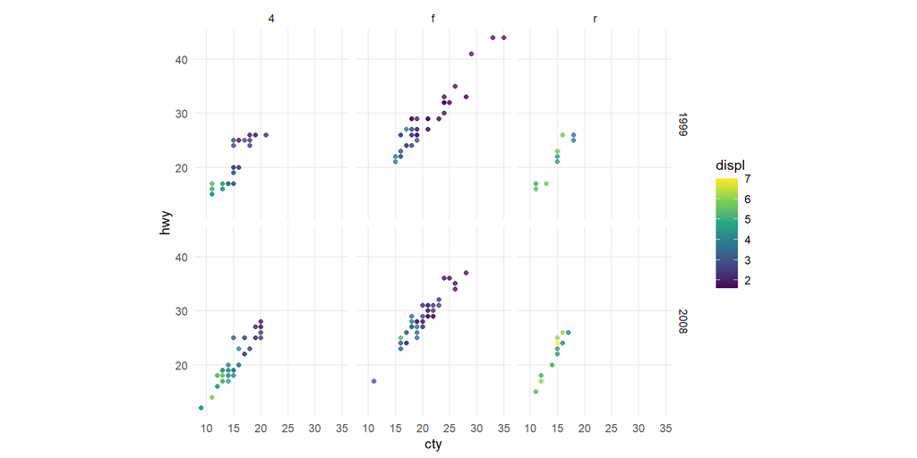

## Summary

| Component | Function(s) | Required |
| --- | --- | --- |
| Data | `ggplot(data)` | Yes |
| Mapping | `aes()` | Yes |
| Layers | `geom_*()`, `stat_*()` | Yes |
| Scales | `scale_*()` | — |
| Facets | `facet_grid/wrap()` | — |
| Coordinates | `coord_*()` | — |
| Theme | `theme_*()`, `theme()` | — |

**To learn more:**

- [ggplot2-book.org](https://ggplot2-book.org/) (free online)
- ggplot2.tidyverse.org

**The ggplot2 recipe:**

1. Start with `ggplot(data)`
2. Map variables with `aes()`
3. Add geometry with `geom_*()`
4. Refine with scales, facets, coordinates, and theme
5. Layer components with `+`

[figure not shown]